# Fit-fonts-and-axes

Steve Simon

October 27, 2016

## My fonts are too big/too small

Sometimes your fonts will be so large that they overlap each other or crowd out the other information in your graph. Fixing this takes a bit of trial and error. Here are some ways you can revise your graph to get more appropriate font sizes.

1. Specify a larger/smaller value for the pointsize argument when you open your graphics device.
2. Trying opening your graphics device with different values for height and width. Fonts that look too big might be better proportioned in a larger graphics window.
3. Use the **cex** argument to increase or decrease the relative size of your fonts.

## Help!! My title or axis labels won’t fit.

There are several possible solutions.

1. You can assign wider margins using the **mar** or **mai** argument in **par**.
2. You can change the orientation of the axis labels with the **las**. Choose among
1. **las=0** both axis labels parallel
2. **las=1** both axis labels horizontal
3. **las=2** both axis labels perpendicular
4. **las=3** both axis labels vertical

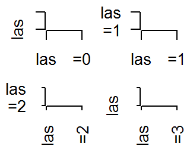

3. change the relative size of the font
1. **cex.axis** for the tick mark labels.
2. **cex.lab** for **xlab** and **ylab**.
3. **cex.main** for the main title
4. **cex.sub** for the subtitle.

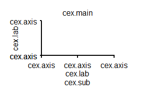